# WVS Wave 7 Data Analysis Notebook

This notebook documents a complete analysis workflow using a cleaned TSV file loaded from GitHub. The goal is to inspect country coverage, clean special missing-value codes, and analyze patterns in life satisfaction by age, country, sex, and confidence in parliament.

## 1. Load Libraries and Data

In the next chunk, we load the required packages and read the TSV file from a public URL that contains only the relevant variables used in this analysis.

```r
library(dplyr)
```

```r
library(ggplot2)
library(tidyr)
library(forcats)

data_url <- "https://raw.githubusercontent.com/cca-cce/osm-comm/refs/heads/main/csv/WVS_Cross-National_Wave_7_csv_v6_0.tsv"
wvs_small <- read.delim(data_url, sep = "\t", stringsAsFactors = FALSE, check.names = FALSE)

glimpse(wvs_small)
```

```
## Rows: 97,220
## Columns: 6
## $ country         <chr> "AND", "AND", "AND", "AND", "AND", "AND", "AND", "AND"…
## $ age             <int> 60, 47, 48, 62, 49, 51, 33, 55, 40, 38, 54, 39, 44, 53…
## $ sex             <int> 2, 1, 1, 2, 1, 2, 2, 1, 2, 2, 1, 1, 2, 2, 2, 1, 1, 2, …
## $ life_sat        <int> 10, 9, 9, 8, 7, 10, 5, 8, 8, 10, 8, 8, 10, 7, 10, 1, 8…
## $ trust_people    <int> 2, 2, 2, 2, 2, 2, 2, 2, 2, 2, 2, 1, 2, 2, 2, 2, 2, 2, …
## $ conf_parliament <int> 1, 4, 3, 3, 2, 2, 4, 4, 3, 4, 2, 2, 4, 1, 2, 4, 3, 4, …
```

```r
summary(wvs_small)
```

```
##    country               age              sex            life_sat
##  Length:97220       Min.   : -5.00   Min.   :-5.000   Min.   :-5.000
##  Class :character   1st Qu.: 29.00   1st Qu.: 1.000   1st Qu.: 6.000
##  Mode  :character   Median : 41.00   Median : 2.000   Median : 7.000
##                     Mean   : 42.93   Mean   : 1.521   Mean   : 7.012
##                     3rd Qu.: 55.00   3rd Qu.: 2.000   3rd Qu.: 9.000
##                     Max.   :103.00   Max.   : 2.000   Max.   :10.000
##   trust_people    conf_parliament
##  Min.   :-5.000   Min.   :-5.000
##  1st Qu.: 1.000   1st Qu.: 2.000
##  Median : 2.000   Median : 3.000
##  Mean   : 1.704   Mean   : 2.653
##  3rd Qu.: 2.000   3rd Qu.: 4.000
##  Max.   : 2.000   Max.   : 4.000
```

## 2. Data Cleaning and Feature Engineering

In the next chunk, we convert `country` to a factor, replace negative survey codes with `NA`, and create analysis-friendly variables for age class and sex labels.

```r
wvs_clean <- wvs_small %>%
  mutate(
    country = as.factor(country),
    age = ifelse(age < 0, NA, age),
    sex = ifelse(sex < 0, NA, sex),
    life_sat = ifelse(life_sat < 0, NA, life_sat),
    trust_people = ifelse(trust_people < 0, NA, trust_people),
    conf_parliament = ifelse(conf_parliament < 0, NA, conf_parliament),
    age_class = case_when(
      is.na(age) ~ NA_character_,
      age >= 16 & age <= 25 ~ "Young",
      age >= 55 ~ "Old",
      TRUE ~ "Middle"
    ),
    age_class = factor(age_class, levels = c("Young", "Middle", "Old")),
    sex_label = case_when(
      sex == 1 ~ "Male",
      sex == 2 ~ "Female",
      TRUE ~ NA_character_
    )
  )

summary(wvs_clean)
```

```
##     country           age              sex           life_sat
##  CAN    : 4018   Min.   : 16.00   Min.   :1.000   Min.   : 1.000
##  IDN    : 3200   1st Qu.: 29.00   1st Qu.:1.000   1st Qu.: 6.000
##  CHN    : 3036   Median : 41.00   Median :2.000   Median : 7.000
##  GBR    : 2609   Mean   : 43.18   Mean   :1.526   Mean   : 7.062
##  USA    : 2596   3rd Qu.: 55.00   3rd Qu.:2.000   3rd Qu.: 9.000
##  TUR    : 2415   Max.   :103.00   Max.   :2.000   Max.   :10.000
##  (Other):79346   NA's   :511      NA's   :95      NA's   :520
##   trust_people   conf_parliament  age_class      sex_label
##  Min.   :1.000   Min.   :1.000   Young :16377   Length:97220
##  1st Qu.:2.000   1st Qu.:2.000   Middle:54215   Class :character
##  Median :2.000   Median :3.000   Old   :26117   Mode  :character
##  Mean   :1.757   Mean   :2.801   NA's  :  511
##  3rd Qu.:2.000   3rd Qu.:4.000
##  Max.   :2.000   Max.   :4.000
##  NA's   :1337    NA's   :3479
```

This cleaning step creates a consistent base table for the rest of the notebook, ensuring that missing data does not bias means and correlations.

## 3. Country Coverage

In the next chunk, we count observations per country and visualize the top 20 countries by sample size to understand the distribution of cases.

```r
country_table <- wvs_clean %>%
  count(country, name = "observations") %>%
  arrange(desc(observations))

head(country_table, 10)
```

```
##    country observations
## 1      CAN         4018
## 2      IDN         3200
## 3      CHN         3036
## 4      GBR         2609
## 5      USA         2596
## 6      TUR         2415
## 7      NLD         2145
## 8      HKG         2075
## 9      BOL         2067
## 10     SGP         2012
```

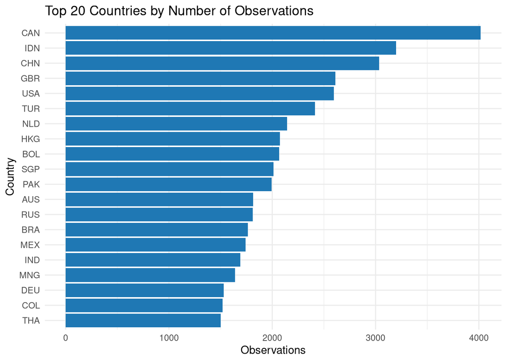

```r
country_table %>%
  slice_head(n = 20) %>%
  ggplot(aes(x = fct_reorder(country, observations), y = observations)) +
  geom_col(fill = "#1f78b4") +
  coord_flip() +
  labs(
    title = "Top 20 Countries by Number of Observations",
    x = "Country",
    y = "Observations"
  ) +
  theme_minimal()
```

The chart shows where most of the sample is concentrated, which is useful context when interpreting global averages.

## 4. Life Satisfaction by Age Class (Global)

In the next chunk, we compute and visualize mean life satisfaction for each age class across the full dataset.

```r
life_sat_table <- wvs_clean %>%
  group_by(age_class) %>%
  summarize(mean_life_sat_world = mean(life_sat, na.rm = TRUE), .groups = "drop")

life_sat_table
```

```
## # A tibble: 4 × 2
##   age_class mean_life_sat_world
##   <fct>                   <dbl>
## 1 Young                    7.07
## 2 Middle                   7.01
## 3 Old                      7.16
## 4 <NA>                     6.65
```

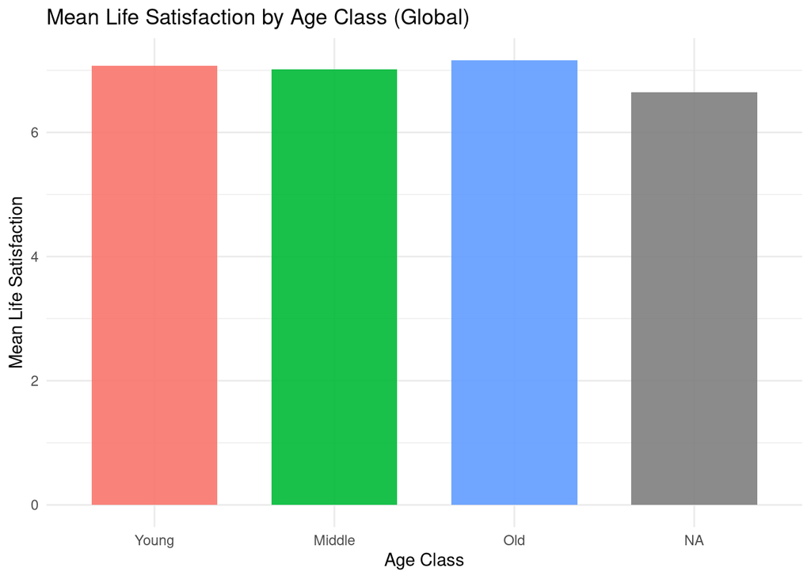

```r
ggplot(life_sat_table, aes(x = age_class, y = mean_life_sat_world, fill = age_class)) +
  geom_col(width = 0.7, alpha = 0.9, show.legend = FALSE) +
  labs(
    title = "Mean Life Satisfaction by Age Class (Global)",
    x = "Age Class",
    y = "Mean Life Satisfaction"
  ) +
  theme_minimal()
```

This summarizes the global age pattern and gives a baseline before country-specific comparison.

## 5. Global vs USA Comparison

In the next chunk, we calculate USA-specific age-class means, join them with global means, and plot both series together.

```r
usa_life_sat_table <- wvs_clean %>%
  filter(country == "USA") %>%
  group_by(age_class) %>%
  summarize(mean_life_sat_usa = mean(life_sat, na.rm = TRUE), .groups = "drop")

life_sat_comparison <- left_join(life_sat_table, usa_life_sat_table, by = "age_class") %>%
  rename(world = mean_life_sat_world, usa = mean_life_sat_usa)

life_sat_comparison
```

```
## # A tibble: 4 × 3
##   age_class world   usa
##   <fct>     <dbl> <dbl>
## 1 Young      7.07  6.78
## 2 Middle     7.01  7.12
## 3 Old        7.16  7.64
## 4 <NA>       6.65 NA
```

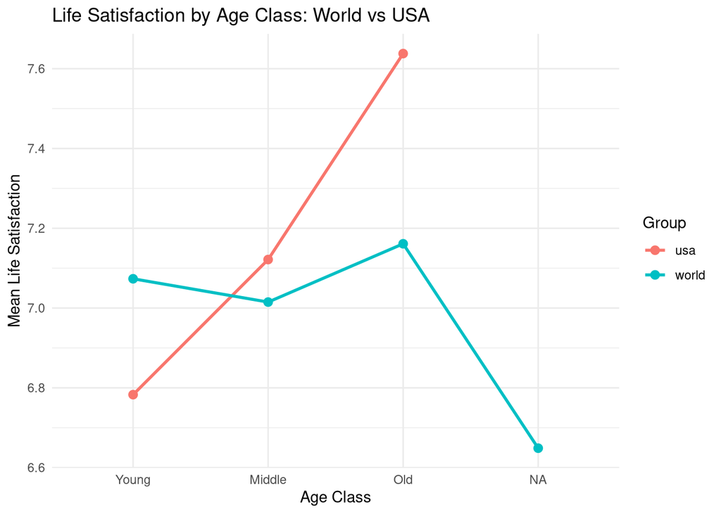

```r
life_sat_comparison_long <- life_sat_comparison %>%
  pivot_longer(cols = c(world, usa), names_to = "group", values_to = "mean_life_sat")

ggplot(life_sat_comparison_long, aes(x = age_class, y = mean_life_sat, color = group, group = group)) +
  geom_line(linewidth = 1) +
  geom_point(size = 2.5) +
  labs(
    title = "Life Satisfaction by Age Class: World vs USA",
    x = "Age Class",
    y = "Mean Life Satisfaction",
    color = "Group"
  ) +
  theme_minimal()
```

This comparison highlights whether the USA follows or diverges from the global age-related life satisfaction pattern.

## 6. Gender Differences Across Age Classes

In the next chunk, we estimate mean life satisfaction by age class and sex, then visualize group differences with side-by-side bars.

```r
life_sat_gender_table <- wvs_clean %>%
  filter(!is.na(sex_label), !is.na(age_class)) %>%
  group_by(age_class, sex_label) %>%
  summarize(mean_life_sat = mean(life_sat, na.rm = TRUE), .groups = "drop")

life_sat_gender_table
```

```
## # A tibble: 6 × 3
##   age_class sex_label mean_life_sat
##   <fct>     <chr>             <dbl>
## 1 Young     Female             7.11
## 2 Young     Male               7.04
## 3 Middle    Female             7.06
## 4 Middle    Male               6.96
## 5 Old       Female             7.13
## 6 Old       Male               7.19
```

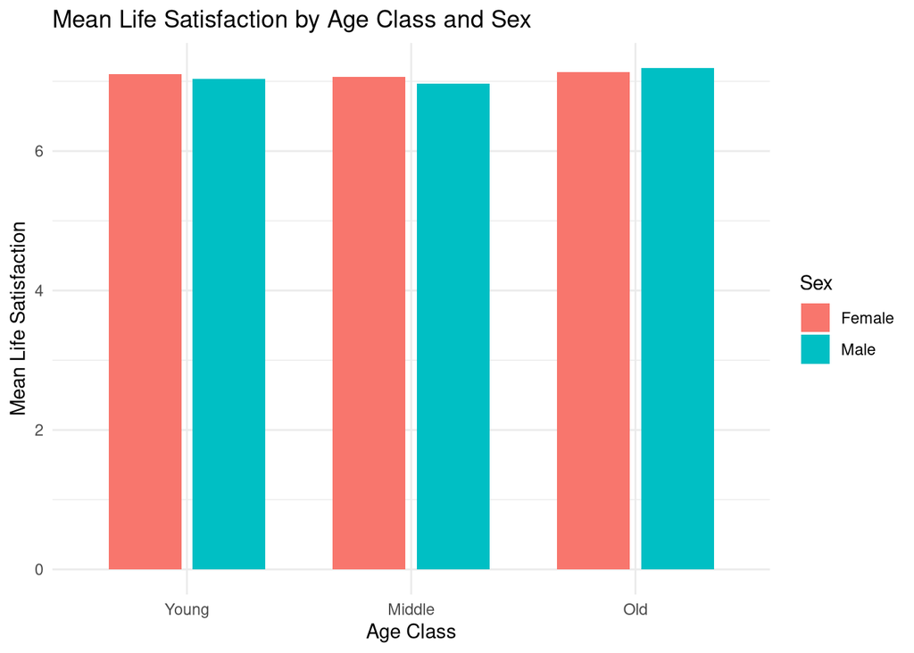

```r
ggplot(life_sat_gender_table, aes(x = age_class, y = mean_life_sat, fill = sex_label)) +
  geom_col(position = position_dodge(width = 0.75), width = 0.65) +
  labs(
    title = "Mean Life Satisfaction by Age Class and Sex",
    x = "Age Class",
    y = "Mean Life Satisfaction",
    fill = "Sex"
  ) +
  theme_minimal()
```

This step extends the age analysis by adding a gender perspective within each age category.

## 7. Correlation Between Life Satisfaction and Confidence in Parliament

In the next chunk, we run a correlation test and create a scatterplot with a fitted linear trend line.

```r
cor_result <- cor.test(wvs_clean$life_sat, wvs_clean$conf_parliament)
cor_result
```

```
##
##  Pearson's product-moment correlation
##
## data:  wvs_clean$life_sat and wvs_clean$conf_parliament
## t = -26.731, df = 93374, p-value < 2.2e-16
## alternative hypothesis: true correlation is not equal to 0
## 95 percent confidence interval:
##  -0.09350682 -0.08077616
## sample estimates:
##         cor
## -0.08714505
```

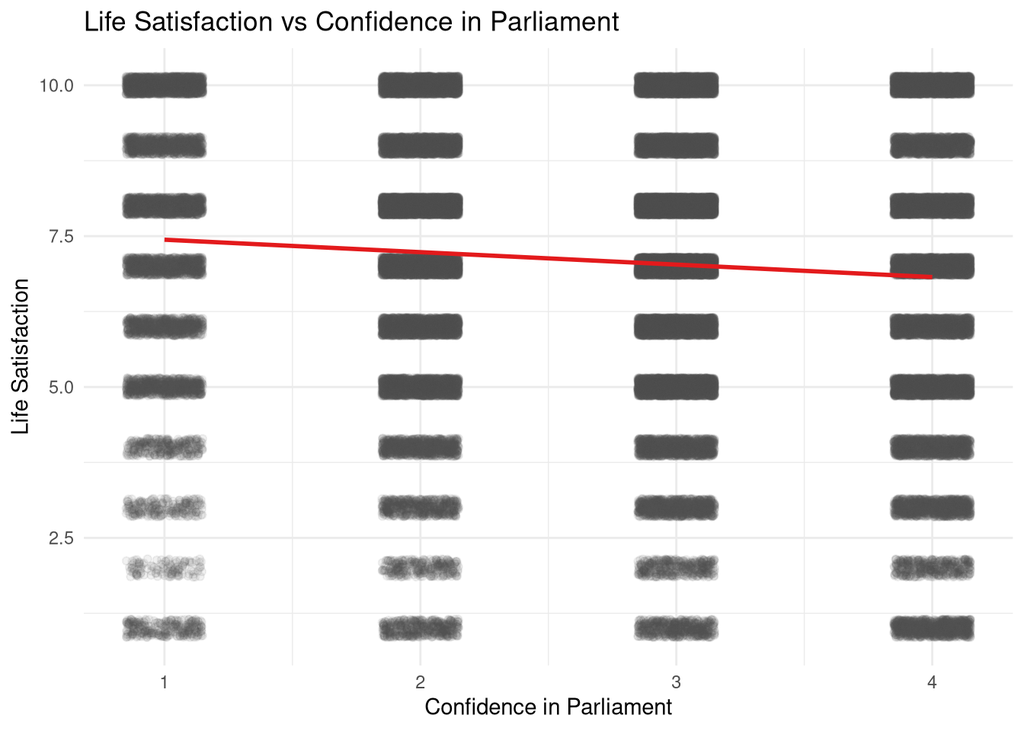

```r
ggplot(wvs_clean, aes(x = conf_parliament, y = life_sat)) +
  geom_jitter(width = 0.15, height = 0.15, alpha = 0.08, color = "#4d4d4d") +
  geom_smooth(method = "lm", se = FALSE, color = "#e31a1c", linewidth = 1) +
  labs(
    title = "Life Satisfaction vs Confidence in Parliament",
    x = "Confidence in Parliament",
    y = "Life Satisfaction"
  ) +
  theme_minimal()
```

The correlation output and fitted line provide a quick check of the strength and direction of association between political confidence and life satisfaction.

## 8. Analysis Narrative Summary

The notebook follows a standard analysis pipeline: 1. Load a compact TSV containing only relevant variables. 2. Clean negative response codes and derive age/sex categories. 3. Describe sample structure by country. 4. Estimate global life-satisfaction patterns by age. 5. Compare global results with USA-specific estimates. 6. Add gender-based differences within age classes. 7. Evaluate linear association between life satisfaction and confidence in parliament.

These steps produce an interpretable and reproducible workflow that can be extended for deeper country-level or subgroup analysis.